# H6: How Is a Sudden Revenue Loss Absorbed?

Expense cuts and balance-sheet drawdown after revenue falls below a three-year baseline, 2019-2024

# Purpose

H5 asked where a surplus goes. This document asks the mirror question about the loss side: **when revenue falls sharply, what absorbs the loss?**

Every dollar of revenue an organization does not receive has to be found somewhere. It comes out of expenses, or it comes out of the balance sheet as a worse surplus — and that worse surplus is itself drawn from cash, receivables, property, investments, or new borrowing. The accounting identity pins the split down exactly, so the estimate is the split itself, not whether it exists.

## What changed in this version, and why

The first version of this document defined a shock as revenue falling at least 20% **below the prior year**. That measure cannot tell a shock apart from the second half of a windfall. An organization that lands a large capital grant, a bequest, or a one-off capital campaign in year *t-1* and returns to its normal level in year *t* records a >20% “drop” while nothing whatever has gone wrong. The v1 estimates were visibly contaminated by this: the headline said organizations *raised* expenses by 9 cents per dollar “lost”, which is what you would expect if a large share of the sample were spending down last year’s windfall rather than absorbing a loss.

Three changes follow from that diagnosis.

**A shock** is an organization-year in which total real revenue falls at least 20% below the organization’s own inflation-adjusted average of the 3 prior tax years.

**Window.** Shocks landing in tax years 2022 and 2023, December year-ends, organizations that filed a full 990 in every year 2019-2023. Because a baseline needs three prior filings, the panel was extended back to tax year 2016 (`dev/panel/panel_build_baseline.R`); that extension is what lets shock years 2019, 2020 and 2021 appear in the contrast table with a clean pre-COVID baseline.

**Scaling.** Everything is divided by **baseline expenses** — the same trailing three-year real average, applied to total expenses. Current-year expenses are one of the outcomes here, so an organization that responds by cutting deeply would shrink its own denominator and bias its expense-cut share toward zero. The baseline is fixed before the shock lands.

```r
suppressMessages({
  library(data.table)
  library(bit64)
  library(knitr)
})
set.seed(params$seed)
fmt <- function(x, d = 3) formatC(x, format = "f", digits = d)
pct <- function(x, d = 1) paste0(formatC(100 * x, format = "f", digits = d), "%")
BW  <- as.integer(params$base_window)
```

# 1. Data, inflation adjustment, and the baseline

Balance-sheet blocks follow H5 exactly: end-of-year minus beginning-of-year, both from the same filing’s Part X, so the two dates share one accounting basis.

| Block | Part X lines |
| --- | --- |
| Cash | cash + savings |
| Other current assets | pledges, accounts receivable, inventories, prepaid |
| Fixed assets | land, buildings, equipment (net) |
| Other assets | total assets minus the three above (investments, intangibles, notes receivable) |
| Long-term debt | tax-exempt bonds + mortgages + unsecured notes |
| Short-term liabilities | accounts payable + grants payable + deferred revenue |
| Other liabilities | total liabilities minus the two above |

Revenue is split into seven components that partition the Part VIII total exactly. The seventh is a residual, so the partition holds by construction.

| Component | Part VIII lines |
| --- | --- |
| Government grants | 1e |
| Membership dues | 1b |
| Fundraising events | 1c (contributions portion) + 8c (net event income) + 9c (net gaming) |
| Other contributions | 1h minus government grants, dues and the 1c events portion (federated campaigns, related organizations, all other) |
| Program revenue | 2g |
| Investments | 3 + 4 (investment and tax-exempt bond income) + 7d (net gain on asset sales) |
| Other revenue | total minus the six above (royalties, net rent, net inventory sales, miscellaneous) |

```r
# Loading, deflating and baseline construction are shared with
# h5-windfall-allocation.Rmd, which measures the other tail of the same
# distribution. If the two documents built their baselines separately they could
# drift apart and stop being comparable, so the construction lives in one file.
source("baseline-prep.R", local = knitr::knit_global())

kable(cpi_table,
      caption = paste0("Deflator applied to every dollar quantity (constant ",
                       params$ref_year, " dollars)"))
```

Deflator applied to every dollar quantity (constant 2023 dollars)

| tax_year | cpi_u | multiplier_to_ref |
| --- | --- | --- |
| 2016 | 240.007 | 1.2696 |
| 2017 | 245.120 | 1.2431 |
| 2018 | 251.107 | 1.2134 |
| 2019 | 255.657 | 1.1918 |
| 2020 | 258.811 | 1.1773 |
| 2021 | 270.970 | 1.1245 |
| 2022 | 292.655 | 1.0412 |
| 2023 | 304.702 | 1.0000 |
| 2024 | 313.689 | 0.9714 |

```r
kable(filings_by_year, format.args = list(big.mark = ","),
      caption = "Full-990 December filings available by tax year, after the extension back to 2016")
```

Full-990 December filings available by tax year, after the extension back to 2016

| TAX_YEAR | filings | organizations |
| --- | --- | --- |
| 2,016 | 98,729 | 98,729 |
| 2,017 | 106,781 | 106,781 |
| 2,018 | 115,312 | 115,312 |
| 2,019 | 128,869 | 128,869 |
| 2,020 | 128,696 | 128,696 |
| 2,021 | 128,755 | 128,755 |
| 2,022 | 128,807 | 128,807 |
| 2,023 | 128,898 | 128,898 |
| 2,024 | 113,696 | 113,696 |

**The baseline is a trailing mean, not a centred one.** `panel990::panel_smooth()` smooths with an odd, centred window, so a three-year smooth of revenue would include the shock year itself and the shock would partly define its own baseline. The baseline here is built only from tax years strictly before the shock, and only when all 3 of them are present as consecutive full-990 filings.

```r
kable(p[, .(org_years = .N, organizations = uniqueN(EIN2)), by = year][order(year)],
      format.args = list(big.mark = ","),
      caption = "Organization-years with a complete three-year baseline")
```

Organization-years with a complete three-year baseline

| year | org_years | organizations |
| --- | --- | --- |
| 2,019 | 92,655 | 92,655 |
| 2,020 | 102,415 | 102,415 |
| 2,021 | 112,937 | 112,937 |
| 2,022 | 126,147 | 126,147 |
| 2,023 | 125,856 | 125,856 |
| 2,024 | 111,068 | 111,068 |

# 2. What a shock looks like against a smoothed baseline

```r
qs <- c(0.001, 0.01, 0.05, 0.10, 0.25, 0.50, 0.75, 0.90, 0.99)
g  <- p$gap   # iqr_sd(), size_band and max_abs_blk all come from baseline-prep.R
dist <- data.table(
  statistic = c("mean", "standard deviation", "median", "robust SD (IQR/1.349)",
                paste0("p", qs * 100)),
  gap = round(c(mean(g), sd(g), median(g), iqr_sd(g), quantile(g, qs)), 4))
kable(dist, caption = "Revenue relative to a three-year inflation-adjusted baseline (0 = exactly on baseline)")
```

Revenue relative to a three-year inflation-adjusted baseline (0 = exactly on baseline)

| statistic | gap |
| --- | --- |
| mean | 3.1131 |
| standard deviation | 1583.8106 |
| median | -0.0032 |
| robust SD (IQR/1.349) | 0.2844 |
| p0.1 | -1.7951 |
| p1 | -0.9880 |
| p5 | -0.6501 |
| p10 | -0.4449 |
| p25 | -0.1806 |
| p50 | -0.0032 |
| p75 | 0.2031 |
| p90 | 0.5773 |
| p99 | 3.4119 |

**The ordinary standard deviation is not usable here, and that is itself worth knowing.** It comes out at 1583.8 because the ratio has a baseline in its denominator: an organization whose three prior years averaged a few thousand dollars and which then receives one large grant produces a gap in the hundreds or thousands. Those cases are real filings, not errors, and they say nothing about the loss side. Every spread statistic below is therefore the robust one, `IQR/1.349`, which equals the standard deviation for a normal distribution and ignores the tail.

```r
by_size <- p[, .(organization_years = .N,
                 median = median(gap),
                 robust_sd = iqr_sd(gap),
                 p10 = quantile(gap, 0.10),
                 sd_of_a_20pct_shortfall = (-params$shock_threshold - median(gap)) / iqr_sd(gap),
                 share_shocked = mean(shock)),
             by = size_band][order(size_band)]
kable(by_size, digits = 3, format.args = list(big.mark = ","),
      caption = "The same 20% rule means very different things at different sizes (baseline revenue bands)")
```

The same 20% rule means very different things at different sizes (baseline revenue bands)

| size_band | organization_years | median | robust_sd | p10 | sd_of_a_20pct_shortfall | share_shocked |
| --- | --- | --- | --- | --- | --- | --- |
| under $100k | 61,737 | -0.017 | 0.561 | -0.747 | -0.327 | 0.337 |
| $100k-500k | 240,144 | -0.012 | 0.306 | -0.456 | -0.614 | 0.249 |
| $500k-2m | 204,036 | 0.001 | 0.275 | -0.403 | -0.730 | 0.219 |
| $2m-10m | 108,100 | 0.002 | 0.246 | -0.396 | -0.823 | 0.207 |
| $10m+ | 57,061 | 0.008 | 0.171 | -0.295 | -1.217 | 0.147 |

```r
z20 <- (-params$shock_threshold - median(g)) / iqr_sd(g)
```

Three things follow, and they matter for how the threshold should be set.

- **A 20% shortfall is not a rare event.** It sits -0.69 robust standard deviations below the median and selects 23.3% of all organization-years — roughly one year in four. Revenue at this population is simply very volatile relative to a three-year mean.
- **The threshold is not size-neutral.** Volatility falls steeply with size: the robust SD is 0.561 for organizations under $100k and 0.171 for those above $10m. The same 20% rule is 0.33 SDs for the smallest band and 1.22 SDs for the largest, so it flags 34% of the smallest organizations against 15% of the largest. A fixed percentage cut point is, in effect, a small-organization filter.
- **What to do about it.** Section 10 shows the absorption split is stable from a 10% threshold to a 50% one, so nothing in this document turns on the choice. But if the index is going to call something a “shock”, 20% against a three-year baseline is too weak a claim on its own, and a size-relative cut point — a fixed number of the organization’s own robust SDs — would flag a comparable share in every size band. That is a change to the index definition, not to this estimate, so it is flagged here rather than made.

## Was the old rule picking up windfall reversions?

```r
rev_tab <- p[shock_t1 == TRUE,
  .(n = .N,
    median_prior_year_vs_baseline = median(prior_windfall),
    share_prior_year_20pct_above_baseline = mean(prior_windfall > 0.20),
    median_current_vs_baseline = median(gap)),
  by = .(also_a_baseline_shock = shock)][order(-also_a_baseline_shock)]
kable(rev_tab, digits = 3,
      caption = "Organization-years the prior-year rule calls a shock, split by whether the baseline rule agrees")
```

Organization-years the prior-year rule calls a shock, split by whether the baseline rule agrees

| also_a_baseline_shock | n | median_prior_year_vs_baseline | share_prior_year_20pct_above_baseline | median_current_vs_baseline |
| --- | --- | --- | --- | --- |
| TRUE | 100997 | 0.007 | 0.253 | -0.453 |
| FALSE | 34180 | 0.304 | 0.685 | -0.095 |

```r
both <- p[, .(t1_rule = sum(shock_t1), baseline_rule = sum(shock),
              both = sum(shock & shock_t1),
              t1_only = sum(shock_t1 & !shock), baseline_only = sum(shock & !shock_t1))]
kable(both, format.args = list(big.mark = ","),
      caption = "Overlap of the two shock definitions, all years")
```

Overlap of the two shock definitions, all years

| t1_rule | baseline_rule | both | t1_only | baseline_only |
| --- | --- | --- | --- | --- |
| 135,177 | 156,179 | 100,997 | 34,180 | 55,182 |

This is the diagnostic that motivated the rewrite. Of the organization-years the prior-year rule flags, 25.3% are **rejected** by the baseline rule, and that rejected group is exactly what the windfall story predicts: their prior year was far above their own baseline (median 0.304), and their current year is close to it (median -0.095). These organizations did not lose anything. They had one big year and went back to normal. The baseline rule also *adds* 55,182 organization-years the prior-year rule missed — organizations in a second or third year of sustained decline, where each year-over-year step is small but the level is far below normal. Those are the cases a shock measure should catch.

## Should there be a maximum?

```r
tail_tab <- data.table(
  bound = c(0.50, 0.75, 0.90, 1.00, 1.50),
  organization_years_below = vapply(c(0.50, 0.75, 0.90, 1.00, 1.50),
                                    function(b) sum(p$gap < -b), 0L))
tail_tab[, share_of_all := organization_years_below / nrow(p)]
tail_tab[, share_of_shocks := organization_years_below / sum(p$shock)]
kable(tail_tab, digits = 5,
      caption = "How many organization-years fall further than a given bound below baseline")
```

How many organization-years fall further than a given bound below baseline

| bound | organization_years_below | share_of_all | share_of_shocks |
| --- | --- | --- | --- |
| 0.50 | 55724 | 0.08304 | 0.35680 |
| 0.75 | 23159 | 0.03451 | 0.14828 |
| 0.90 | 12228 | 0.01822 | 0.07829 |
| 1.00 | 2279 | 0.00340 | 0.01459 |
| 1.50 | 919 | 0.00137 | 0.00588 |

```r
cat("minimum gap observed:", fmt(min(p$gap), 2),
    " | organization-years with revenue below zero:", sum(p$R < 0), "\n")
```

```
## minimum gap observed: -59197.71  | organization-years with revenue below zero: 2279
```

**Yes, and it should be at 1.00.** Total revenue on Part VIII is a *net* figure: a large realized loss on an asset sale enters negatively and can push reported total revenue below zero, which makes the gap smaller than -1 without the organization having lost a single dollar of operating income. A gap of exactly -1 means “revenue this year was zero”; anything beyond that is an accounting artefact rather than a deeper shock, and because the gap is the denominator of every share in this document, those rows have unbounded leverage. Capping at -1 removes 2,279 organization-years (0.340% of the sample). The 1st/99th percentile trim in section 3 does most of the work in practice; the bound is a guard against the pathological tail rather than a live constraint.

# 3. Sample and trimming

Outliers are handled by **dropping organization-years, not by clipping values** — the same rule H5 arrived at. Winsorizing each component separately breaks the identity the whole design rests on: the clipped parts stop summing to the clipped total and the coefficients stop adding up.

```r
# Every channel is a DEVIATION FROM THE ORGANIZATION'S OWN BASELINE, signed so
# that a positive number always means "this is where a dollar of the shortfall
# came from". For revenue lines and assets that is baseline minus actual (the
# line came in below normal; the asset grew less than normal, or shrank). For
# liabilities it is actual minus baseline (debt grew more than normal).
# `capacity` is the stock or flow the channel is drawn from.
CH <- rbindlist(list(
  data.table(name="gov",       label="Government grants",         actual="gov",       base="base_gov",       capacity="base_gov",       sign=1, group="revenue"),
  data.table(name="dues",      label="Membership dues",           actual="dues",      base="base_dues",      capacity="base_dues",      sign=1, group="revenue"),
  data.table(name="events",    label="Fundraising events",        actual="events",    base="base_events",    capacity="base_events",    sign=1, group="revenue"),
  data.table(name="contr_oth", label="Other contributions",       actual="contr_oth", base="base_contr_oth", capacity="base_contr_oth", sign=1, group="revenue"),
  data.table(name="program",   label="Program revenue",           actual="program",   base="base_program",   capacity="base_program",   sign=1, group="revenue"),
  data.table(name="invest",    label="Investments",               actual="invest",    base="base_invest",    capacity="base_invest",    sign=1, group="revenue"),
  data.table(name="other",     label="Other revenue",             actual="other",     base="base_other",     capacity="base_other",     sign=1, group="revenue"),
  data.table(name="cut_E",     label="Expense cuts",              actual="E",         base="base_E",         capacity="base_E",         sign=1, group="absorption"),
  data.table(name="cut_prog",  label="Program services",          actual="program_expenses",     base="base_program_expenses",     capacity="base_program_expenses",     sign=1, group="expense"),
  data.table(name="cut_admin", label="Management and general",    actual="admin_expenses",       base="base_admin_expenses",       capacity="base_admin_expenses",       sign=1, group="expense"),
  data.table(name="cut_fund",  label="Fundraising",               actual="fundraising_expenses", base="base_fundraising_expenses", capacity="base_fundraising_expenses", sign=1, group="expense"),
  data.table(name="cut_unall", label="Unallocated",               actual="unallocated_expenses", base="base_unallocated_expenses", capacity="base_unallocated_expenses", sign=1, group="expense"),
  data.table(name="bs_cash",   label="Cash",                      actual="d_cash",          base="base_d_cash",          capacity="boy_cash",          sign=1,  group="block"),
  data.table(name="bs_oca",    label="Receivables, prepaid",      actual="d_other_current", base="base_d_other_current", capacity="boy_other_current", sign=1,  group="block"),
  data.table(name="bs_fixed",  label="Property and equipment",    actual="d_fixed",         base="base_d_fixed",         capacity="boy_fixed",         sign=1,  group="block"),
  data.table(name="bs_othass", label="Investments, other assets", actual="d_other_assets",  base="base_d_other_assets",  capacity="boy_other_assets",  sign=1,  group="block"),
  data.table(name="bs_lt",     label="Long-term debt",            actual="d_lt",            base="base_d_lt",            capacity="boy_lt",            sign=-1, group="block"),
  data.table(name="bs_st",     label="Short-term liabilities",    actual="d_st",            base="base_d_st",            capacity="boy_st",            sign=-1, group="block"),
  data.table(name="bs_othli",  label="Other liabilities",         actual="d_other_liab",    base="base_d_other_liab",    capacity="boy_other_liab",    sign=-1, group="block")
))
CAP_PHRASE <- c(cut_E = "its normal budget", bs_cash = "the cash it held",
                bs_oca = "the receivables it held", bs_fixed = "the property it held",
                bs_othass = "the investments it held", bs_lt = "the long-term debt it owed",
                bs_st = "the short-term liabilities it owed", bs_othli = "the other liabilities it owed")

build_channels <- function(z) {
  z <- copy(z)
  z[, dol_loss := base_R - R][, s_loss := dol_loss / base_E]
  for (i in seq_len(nrow(CH))) {
    r <- CH[i]
    d <- if (r$sign == 1) z[[r$base]] - z[[r$actual]] else z[[r$actual]] - z[[r$base]]
    z[[paste0("dol_", r$name)]] <- d
    z[[paste0("s_",   r$name)]] <- d / z$base_E
    z[[paste0("cap_", r$name)]] <- z[[r$capacity]]
  }
  z[, dol_surp := dol_loss - dol_cut_E][, s_surp := dol_surp / base_E]
  z[, dol_na := base_d_na - d_na][, s_na := dol_na / base_E]
  z[]
}
p <- build_channels(p)

kable(data.table(
  check = c("revenue components sum to the shortfall",
            "expense lines sum to the expense cut",
            "balance-sheet blocks sum to the net-assets shortfall"),
  max_abs_error_dollars = c(
    p[, max(abs(dol_gov + dol_dues + dol_events + dol_contr_oth + dol_program + dol_invest + dol_other - dol_loss))],
    p[, max(abs(dol_cut_prog + dol_cut_admin + dol_cut_fund + dol_cut_unall - dol_cut_E))],
    p[, max(abs(dol_bs_cash + dol_bs_oca + dol_bs_fixed + dol_bs_othass + dol_bs_lt + dol_bs_st + dol_bs_othli - dol_na))])),
  digits = 6, caption = "Adding-up checks, before any trimming (constant dollars)")
```

Adding-up checks, before any trimming (constant dollars)

| check | max_abs_error_dollars |
| --- | --- |
| revenue components sum to the shortfall | 0.000023 |
| expense lines sum to the expense cut | 0.000024 |
| balance-sheet blocks sum to the net-assets shortfall | 15.963174 |

A third rule is needed beyond the two H5 used. Trimming on the shortfall and on the *net* balance-sheet movement is not enough, because the blocks can offset each other: an organization-year with a colossal swing into investments and an equal swing out of cash has a small net movement and survives both filters while carrying enormous leverage over any single block’s coefficient. The scaled block channels reach six figures at their extremes. So organization-years in the top 1% of the largest absolute block movement are dropped as well. On the headline 2022-2023 estimate this changes almost nothing (it removes 79 rows and moves the expense-cut share by 0.002), but it is what makes the early shock years in section 10 readable at all — the 2019 investments channel goes from -14.0 to -0.12 once the handful of extreme rows are gone.

```r
trim_sample <- function(z, trim = TRUE, bound = params$max_shock) {
  if (!is.null(bound)) z <- z[gap >= -bound]
  if (!trim) return(z[])
  # `:=` by group assigns back to the right rows; a grouped select would return
  # the flags in group order and misalign them when years are interleaved.
  z[, keep := {
    ql <- quantile(s_loss, c(0.01, 0.99), na.rm = TRUE)
    qa <- quantile(s_na,   c(0.01, 0.99), na.rm = TRUE)
    qb <- quantile(max_abs_blk, 0.99, na.rm = TRUE)
    s_loss >= ql[[1]] & s_loss <= ql[[2]] & s_na >= qa[[1]] & s_na <= qa[[2]] &
      max_abs_blk <= qb
  }, by = year]
  z <- z[keep == TRUE]; z[, keep := NULL]; z[]
}
shocked <- function(years) trim_sample(p[year %in% years & shock == TRUE])
main_s  <- shocked(2022:2023)
cat("shocked organization-years, 2022-2023:", format(nrow(main_s), big.mark = ","),
    " organizations:", format(uniqueN(main_s$EIN2), big.mark = ","), "\n")
```

```
## shocked organization-years, 2022-2023: 58,222  organizations: 44,489
```

Trimming is applied *after* selecting shocked organization-years, so the percentiles are those of the shocked distribution, not of all filers.

# 4. Three ways to read the numbers

Three estimands answer different questions, and this document reports all three because they can disagree.

- **Cents per dollar of shortfall (the headline).** The total dollars that flowed through a channel across the shocked sample, divided by the total dollars of shortfall. Because each channel is a component of the shortfall row by row, these shares sum to exactly 1. This is the quantity the figure shows.
- **Per cent of its own capacity.** The same dollars, divided by what that channel had to give: the stock at the start of the year for a balance-sheet block, the baseline level for a revenue or expense line. This is the column that separates “drew a lot because it had a lot” from “drew down most of what it had”.
- **Marginal response (OLS).** The slope of the channel on the size of the shortfall, within the shocked sample. This answers “a deeper shock is absorbed how differently”, which is not the same as “the average shock is absorbed how”. Standard errors are HC1.

```r
# ols() is defined in baseline-prep.R (HC1 standard errors).
share_of_avg <- function(s, nm) mean(s[[paste0("s_", nm)]]) / mean(s$s_loss)
pct_capacity <- function(s, nm) {
  cap <- sum(s[[paste0("cap_", nm)]])
  if (!is.finite(cap) || cap <= 0) return(NA_real_)
  sum(s[[paste0("dol_", nm)]]) / cap
}
marginal <- function(s, nm) {
  f <- ols(s[[paste0("s_", nm)]], cbind(intercept = 1, loss = s$s_loss))
  c(b = f$b[["loss"]], se = f$se[["loss"]])
}
channel_table <- function(s, names_vec) {
  rbindlist(lapply(names_vec, function(nm) {
    m <- marginal(s, nm)
    data.table(channel = CH[name == nm, label],
               cents_per_dollar = share_of_avg(s, nm),
               pct_of_capacity  = pct_capacity(s, nm),
               marginal = m[["b"]], se = m[["se"]])
  }))
}
```

# 5. Where the shortfall came from

Which revenue lines came in below baseline. The seven components sum to the total shortfall by construction, so the shares sum to 1. A **negative** entry means that line came in *above* its own baseline during the shock year — it partly offset the loss rather than causing it.

```r
src <- channel_table(main_s, CH[group == "revenue", name])
kable(src, digits = 3,
      caption = "Which revenue lines fell short, 2022-2023 shocks (positive = a source of the shortfall)")
```

Which revenue lines fell short, 2022-2023 shocks (positive = a source of the shortfall)

| channel | cents_per_dollar | pct_of_capacity | marginal | se |
| --- | --- | --- | --- | --- |
| Government grants | 0.082 | 0.461 | 0.061 | 0.008 |
| Membership dues | 0.015 | 0.226 | 0.002 | 0.002 |
| Fundraising events | 0.019 | 0.100 | 0.015 | 0.003 |
| Other contributions | 0.503 | 0.478 | 0.620 | 0.014 |
| Program revenue | 0.119 | 0.349 | 0.034 | 0.006 |
| Investments | 0.205 | 0.672 | 0.210 | 0.011 |
| Other revenue | 0.058 | 0.652 | 0.058 | 0.008 |

```r
cat("sum of shares:", fmt(sum(src$cents_per_dollar)), "\n")
```

```
## sum of shares: 1.000
```

# 6. First-line absorption: expenses or the balance sheet

The identity `revenue - expenses = surplus` means a shortfall in revenue must show up either as expenses coming in below their own baseline, or as a surplus below its own baseline. These two shares sum to exactly 1. That is a check on the code, not a finding — if it fails, something upstream is wrong.

**How to read the sign.** Both columns are positive numbers, and both describe money that did not move as it normally would:

- **Expense cuts** = baseline expenses minus actual expenses. Positive means the organization spent **less** than its own three-year norm — it cut. Negative would mean it spent *more* than normal despite the shortfall.
- **Shortfall run through the surplus** = the rest. Positive means the surplus came in below its norm, which is to say the gap was carried on the balance sheet rather than closed by spending less.

A split of 0.60 / 0.40 therefore reads: of each dollar that did not arrive, 60 cents was matched by spending that did not happen, and 40 cents was absorbed by the balance sheet.

```r
ec <- share_of_avg(main_s, "cut_E")
ws <- mean(main_s$s_surp) / mean(main_s$s_loss)
mE <- marginal(main_s, "cut_E")
absorb <- data.table(
  channel = c("Expense cuts (spending below its own baseline)",
              "Shortfall run through the surplus (carried on the balance sheet)"),
  cents_per_dollar = c(ec, ws),
  pct_of_capacity  = c(pct_capacity(main_s, "cut_E"), NA_real_),
  marginal = c(mE[["b"]], 1 - mE[["b"]]),
  se = c(mE[["se"]], mE[["se"]]))
kable(absorb, digits = 3,
      caption = "Of each dollar of revenue shortfall, how much is matched by lower spending vs. carried on the balance sheet")
```

Of each dollar of revenue shortfall, how much is matched by lower spending vs. carried on the balance sheet

| channel | cents_per_dollar | pct_of_capacity | marginal | se |
| --- | --- | --- | --- | --- |
| Expense cuts (spending below its own baseline) | 0.104 | 0.229 | -0.155 | 0.009 |
| Shortfall run through the surplus (carried on the balance sheet) | 0.896 |  | 1.155 | 0.009 |

```r
cat("identity check, shares sum to:", fmt(ec + ws), "\n")
```

```
## identity check, shares sum to: 1.000
```

The `pct_of_capacity` column on the first row is the expense cut measured against the organization’s own normal budget: it says how big a retrenchment this is in the only units that matter to a manager.

## Which expenses are cut

The four functional lines sum to the total expense cut.

```r
excut <- channel_table(main_s, CH[group == "expense", name])
kable(excut, digits = 3,
      caption = "Where the expense cut falls (positive = that line came in below its baseline)")
```

Where the expense cut falls (positive = that line came in below its baseline)

| channel | cents_per_dollar | pct_of_capacity | marginal | se |
| --- | --- | --- | --- | --- |
| Program services | 0.083 | 0.247 | -0.124 | 0.009 |
| Management and general | 0.004 | 0.069 | -0.023 | 0.004 |
| Fundraising | 0.004 | 0.043 | -0.001 | 0.001 |
| Unallocated | 0.014 | 0.257 | -0.007 | 0.001 |

```r
cat("sums to the expense-cut share:", fmt(sum(excut$cents_per_dollar)),
    " vs. ", fmt(ec), "\n")
```

```
## sums to the expense-cut share: 0.104  vs.  0.104
```

Program services carry most of the cut in cents-per-dollar terms simply because they are most of the budget. The `pct_of_capacity` column is the more informative quantity: it is the cut relative to each line’s own baseline, which says whether administration and fundraising are protected or cut harder than programs.

# 7. Where the balance sheet absorbs it

The surplus shortfall has to be drawn from somewhere, and the same identity as H5 applies: asset-side changes minus liability-side changes equal the change in net assets. Signs are set so that **a positive number is a source of funds**: an asset that grew less than normal (or shrank), or a liability that grew more than normal.

Each block enters as its movement during the shock year measured against *its own baseline movement*. An organization that normally adds $40k to cash a year and this year added nothing has found $40k, even though its cash did not fall. Comparing the movement to zero instead of to its baseline would miss that entirely.

```r
bs <- channel_table(main_s, CH[group == "block", name])
blk_side <- setNames(ifelse(CH[group == "block", sign] == 1, "asset", "liability"),
                     CH[group == "block", label])
bs[, side := blk_side[channel]]
kable(bs[, .(channel, side, cents_per_dollar, pct_of_capacity, marginal, se)], digits = 3,
      caption = "Which balance-sheet blocks fund the shortfall (positive = a source of funds)")
```

Which balance-sheet blocks fund the shortfall (positive = a source of funds)

| channel | side | cents_per_dollar | pct_of_capacity | marginal | se |
| --- | --- | --- | --- | --- | --- |
| Cash | asset | 0.443 | 0.270 | 0.428 | 0.025 |
| Receivables, prepaid | asset | 0.045 | 0.140 | 0.046 | 0.010 |
| Property and equipment | asset | 0.109 | 0.039 | 0.183 | 0.018 |
| Investments, other assets | asset | 0.573 | 0.131 | 0.606 | 0.028 |
| Long-term debt | liability | 0.012 | 0.008 | 0.021 | 0.009 |
| Short-term liabilities | liability | 0.008 | 0.048 | 0.002 | 0.004 |
| Other liabilities | liability | 0.007 | -0.137 | 0.020 | 0.006 |

```r
# Needed for the revaluation note below; section 10 recomputes these as part of
# the full year-by-year table.
inv_22 <- share_of_avg(shocked(2022), "bs_othass")
inv_23 <- share_of_avg(shocked(2023), "bs_othass")

ident <- data.table(
  blocks_net = sum(bs$cents_per_dollar),
  net_assets_direct = mean(main_s$s_na) / mean(main_s$s_loss),
  surplus_shortfall = ws,
  n = nrow(main_s))
kable(ident, digits = 3,
      caption = "Identity check: blocks net vs. the direct net-assets shortfall vs. the surplus shortfall")
```

Identity check: blocks net vs. the direct net-assets shortfall vs. the surplus shortfall

| blocks_net | net_assets_direct | surplus_shortfall | n |
| --- | --- | --- | --- |
| 1.196 | 1.196 | 0.896 | 58222 |

The first two columns must agree: they are the same quantity computed two ways. The third need not — net assets also move with unrealized investment gains, prior-period adjustments, and donated capital, none of which pass through the surplus. The gap between them is that non-operating drift, and it is worth reading rather than dismissing.

The `pct_of_capacity` column is where the absorptive-capacity reading lives. Two blocks can contribute the same cents per dollar while one has given up a large fraction of its stock and the other a trivial one; only the second column distinguishes a block that is nearly exhausted from a block that has barely been touched. Cash and investments illustrate the point directly: they contribute roughly comparable cents per dollar, but cash gives up 27.0% of the stock it started with against 13.1% for investments. Cash is doing far more of the work relative to what there is of it.

**The two columns weight organizations differently.** `cents_per_dollar` is a ratio of means of *scaled* channels, so organizations enter roughly alike regardless of size; `pct_of_capacity` is a ratio of raw dollar totals and is therefore dominated by the largest organizations in the sample. On this table they agree in sign everywhere except other liabilities, where both figures are near zero, but the distinction matters when reading any single row: the cents-per-dollar column is the behavioural estimate and the capacity column is the sector aggregate. The companion document `h5-windfall-allocation.Rmd` has a case where the two genuinely disagree in sign.

**One caveat on the investments block, which the year-by-year table in section 10 makes unavoidable.** Part X reports assets at fair value, so the movement in “investments, other assets” mixes two different things: deliberate liquidation to cover a shortfall, and market revaluation that would have happened anyway. The sign convention cannot tell them apart, and in a year when markets fall, a portfolio that was never touched still registers as a large source of funds. That is most of why this channel swings from 1.130 in 2022 — a year markets fell sharply — to -0.082 in 2023. Read cash, receivables and borrowing as behaviour; read the investments row as behaviour plus the market, and prefer its `pct_of_capacity` column, which at least scales the movement by the portfolio it came from.

# 8. Do reserves buffer the cut?

This is the question the memo singled out. The reserves dimension of the index is interpreted as a buffer, which is a claim about behaviour *within* organizations: an organization with more months of cash on hand should be able to absorb a shock without cutting programs as deeply. If high- and low-reserve organizations cut the same way, the dimension is measuring size or sector, not resilience.

Reserves are measured at the beginning of the shock year — months of cash on hand against **baseline** expenses — so the grouping is fixed before the shock lands.

```r
# Rank-based terciles: quantile breaks collapse when many organizations report
# the same months of cash (zero, most often), which a cut() on values cannot survive.
main_s[, reserve_group := factor(c("low", "middle", "high")[
  pmin(3L, 1L + floor(3 * (frank(months_cash_boy, ties.method = "first") - 1) / .N))],
  levels = c("low", "middle", "high"))]
res <- rbindlist(lapply(levels(main_s$reserve_group), function(g) {
  s <- main_s[reserve_group == g]
  data.table(reserves = g, n = nrow(s),
             median_months_cash = median(s$months_cash_boy),
             expense_cut = share_of_avg(s, "cut_E"),
             program_cut = share_of_avg(s, "cut_prog"),
             cash_drawdown = share_of_avg(s, "bs_cash"),
             cash_pct_of_capacity = pct_capacity(s, "bs_cash"),
             borrowing = share_of_avg(s, "bs_lt") + share_of_avg(s, "bs_st"))
}))
kable(res, digits = 3,
      caption = "Absorption by beginning-of-year reserves (cents per dollar of shortfall)")
```

Absorption by beginning-of-year reserves (cents per dollar of shortfall)

| reserves | n | median_months_cash | expense_cut | program_cut | cash_drawdown | cash_pct_of_capacity | borrowing |
| --- | --- | --- | --- | --- | --- | --- | --- |
| low | 19408 | 1.589 | 0.393 | 0.321 | -0.087 | -0.163 | 0.054 |
| middle | 19407 | 7.425 | 0.179 | 0.148 | 0.187 | 0.146 | 0.003 |
| high | 19407 | 26.476 | -0.105 | -0.093 | 0.898 | 0.482 | 0.009 |

**Holding the comparison together.** The table above compares different organizations, so a reserve difference could be a size or sector difference. A shocked organization rarely appears twice, so organization fixed effects are not available on the shocked sample alone; instead the shock indicator is interacted with reserves on *all* 2022-2023 organization-years with a baseline, which keeps organizations that had a shock in one year and not the other in the comparison.

```r
all_p <- trim_sample(p[year %in% 2022:2023])
all_p[, high_reserve := as.numeric(months_cash_boy > median(months_cash_boy))]
all_p[, big_loss := as.numeric(shock)]
W <- cbind(intercept = 1, big_loss = all_p$big_loss, high = all_p$high_reserve,
           big_x_high = all_p$big_loss * all_p$high_reserve)
inter <- rbindlist(lapply(c("s_cut_E", "s_cut_prog", "s_bs_cash"), function(v) {
  f <- ols(all_p[[v]], W)
  data.table(outcome = CH[name == sub("^s_", "", v), label],
             shock_effect = f$b[["big_loss"]], se = f$se[["big_loss"]],
             extra_if_high_reserve = f$b[["big_x_high"]], se_interaction = f$se[["big_x_high"]])
}))
kable(inter, digits = 4,
      caption = "Shock effect and its interaction with high reserves, all 2022-2023 organization-years")
```

Shock effect and its interaction with high reserves, all 2022-2023 organization-years

| outcome | shock_effect | se | extra_if_high_reserve | se_interaction |
| --- | --- | --- | --- | --- |
| Expense cuts | 0.3567 | 0.0028 | -0.0968 | 0.0046 |
| Program services | 0.2918 | 0.0026 | -0.0861 | 0.0042 |
| Cash | 0.0316 | 0.0028 | 0.3412 | 0.0088 |

# 9. Shocks to a single revenue component

The sections above treat a shock as a fall in total revenue, whatever its source. But a government grant that ends, a membership base that erodes, and an investment portfolio that turns down are different events, and there is no reason to expect them to be absorbed the same way. This section isolates them.

**Definition.** A component shock is an organization-year in which one component falls at least 33% below **its own** three-year baseline, *and* that fall is worth at least 10% of the organization’s baseline **total** revenue. The first condition makes it a real disruption to that revenue stream; the second keeps it material to the organization overall. The total-revenue threshold is deliberately looser here (10% rather than 20%): requiring a 20% total-revenue shock as well would throw away every organization that lost a major funder and partly replaced it, which is precisely the interesting case.

```r
COMPS <- CH[group == "revenue"]
comp_flag <- function(z, nm) {
  base_c <- z[[paste0("base_", nm)]]
  drop   <- z[[paste0("dol_", nm)]]          # baseline minus actual, in dollars
  ok <- is.finite(base_c) & is.finite(drop) & base_c > 0
  ok & (drop / base_c) >= params$comp_share & (drop / z$base_R) >= params$comp_material
}
pool  <- p[year %in% 2022:2023]
flags <- vapply(COMPS$name, function(nm) comp_flag(pool, nm), logical(nrow(pool)))
pool[, nflags := rowSums(flags)]

kable(pool[, .(organization_years = .N), by = .(component_shocks = nflags)][order(component_shocks)],
      format.args = list(big.mark = ","),
      caption = "How many revenue components are shocked in the same organization-year")
```

How many revenue components are shocked in the same organization-year

| component_shocks | organization_years |
| --- | --- |
| 0 | 163,688 |
| 1 | 73,847 |
| 2 | 13,335 |
| 3 | 1,081 |
| 4 | 50 |
| 5 | 2 |

```r
kable(data.table(
  any_component_shock = sum(pool$nflags > 0),
  total_revenue_shock = sum(pool$shock),
  both = sum(pool$nflags > 0 & pool$shock),
  component_only = sum(pool$nflags > 0 & !pool$shock),
  total_only = sum(pool$shock & pool$nflags == 0)),
  format.args = list(big.mark = ","),
  caption = "Component shocks against the total-revenue shock, 2022-2023")
```

Component shocks against the total-revenue shock, 2022-2023

| any_component_shock | total_revenue_shock | both | component_only | total_only |
| --- | --- | --- | --- | --- |
| 88,315 | 61,445 | 49,693 | 38,622 | 11,752 |

The flags are not mutually exclusive — an organization can lose a government grant and its program revenue in the same year — and the table above says how often that happens. The estimates below therefore describe “organization-years in which this component was shocked”, not a partition of the sample.

## The denominator has to change

Everywhere above, channels are expressed per dollar of *total* revenue shortfall. That denominator does not survive here, and the reason is the most interesting thing in this section: **when one revenue line collapses, total revenue often does not fall.** Organizations that lose a third or more of their membership dues make almost all of it up elsewhere, and organizations that lose their fundraising events end the year with total revenue *above* baseline on average. Dividing by a mean shortfall that is near zero, or negative, produces ratios that are arithmetically correct and completely meaningless — an early version of this table reported a -1.03 expense-cut share for event losses for exactly that reason.

So each component is scaled by **its own dollar fall**, and the first question asked is how much of that fall ever reached the bottom line:

- **Replaced by other revenue** — the share of the lost dollars offset by other lines coming in above their own baselines.
- **Expense cuts** — the share matched by spending below baseline.
- **Run through the surplus** — the remainder, carried on the balance sheet.

These three sum to exactly 1 by the same identity used throughout, and the balance-sheet columns are on the same per-dollar-of-line-lost scale.

```r
comp_abs <- rbindlist(lapply(seq_len(nrow(COMPS)), function(i) {
  nm <- COMPS$name[i]
  s  <- trim_sample(pool[flags[, nm]])
  if (nrow(s) < 200)
    return(data.table(component = COMPS$label[i], n = nrow(s)))
  fall <- mean(s[[paste0("dol_", nm)]])      # average dollars lost from this line
  data.table(
    component = COMPS$label[i], n = nrow(s), orgs = uniqueN(s$EIN2),
    median_line_fall = median(s[[paste0("dol_", nm)]] / s[[paste0("base_", nm)]]),
    replaced_by_other_revenue = 1 - mean(s$dol_loss) / fall,
    expense_cut = mean(s$dol_cut_E) / fall,
    surplus     = mean(s$dol_surp)  / fall,
    program_cut = mean(s$dol_cut_prog) / fall,
    cash        = mean(s$dol_bs_cash) / fall,
    cash_pct_cap = pct_capacity(s, "bs_cash"),
    borrowing   = (mean(s$dol_bs_lt) + mean(s$dol_bs_st)) / fall)
}), fill = TRUE)
kable(comp_abs, digits = 3,
      caption = "How a shock to each revenue component is absorbed (per dollar lost from that line)")
```

How a shock to each revenue component is absorbed (per dollar lost from that line)

| component | n | orgs | median_line_fall | replaced_by_other_revenue | expense_cut | surplus | program_cut | cash | cash_pct_cap | borrowing |
| --- | --- | --- | --- | --- | --- | --- | --- | --- | --- | --- |
| Government grants | 15210 | 11385 | 0.990 | 0.367 | 0.255 | 0.378 | 0.249 | 0.236 | 0.159 | -0.032 |
| Membership dues | 3107 | 2381 | 1.000 | 0.951 | -0.100 | 0.149 | -0.040 | 0.146 | 0.083 | 0.027 |
| Fundraising events | 4432 | 3580 | 1.000 | 1.170 | -0.431 | 0.261 | -0.397 | 0.368 | 0.121 | -0.030 |
| Other contributions | 35723 | 27391 | 0.647 | 0.033 | 0.116 | 0.851 | 0.117 | 0.320 | 0.315 | -0.015 |
| Program revenue | 13346 | 10311 | 0.697 | 0.039 | 0.848 | 0.113 | 0.617 | 0.078 | 0.116 | 0.038 |
| Investments | 17023 | 13004 | 0.795 | -0.117 | 0.133 | 0.984 | 0.067 | 0.157 | 0.130 | -0.002 |
| Other revenue | 10324 | 8188 | 0.994 | 0.212 | -0.007 | 0.795 | -0.026 | -0.158 | -0.112 | 0.378 |

```r
cat("replaced + expense cut + surplus = ",
    paste(fmt(comp_abs$replaced_by_other_revenue + comp_abs$expense_cut + comp_abs$surplus),
          collapse = ", "), "\n")
```

```
## replaced + expense cut + surplus =  1.000, 1.000, 1.000, 1.000, 1.000, 1.000, 1.000
```

The heterogeneity here is the finding, and it is much larger than anything in the pooled estimate.

- **Program revenue behaves completely differently from everything else.** Of a dollar of lost program revenue, 0.848 is matched by lower spending — against 0.039 replaced and only 0.113 carried on the balance sheet. That is what you would expect if program revenue and program cost are two sides of the same activity: serve fewer clients, bill less, spend less. It is the one component where a revenue fall is genuinely a scale decision rather than a financing problem.
- **Small contributed lines are absorbed by substitution, not by retrenchment.** Membership dues (0.951 replaced) and fundraising events (1.170) are almost entirely made up elsewhere. A replacement share above 1 means the organizations that lost these lines were, on average, growing other revenue faster than they lost them.
- **Government grants sit in between**: 0.367 replaced, 0.255 cut, 0.378 on the balance sheet — a genuine three-way split, and the case where the buffer question in section 8 bites hardest.
- **Investment falls barely touch operations.** 0.984 runs straight through the surplus, which is what should happen: a portfolio that lost value does not change what the organization can deliver this year, and the expense-cut share is correspondingly small.

```r
# The materiality rule can be read two ways: the FALL is worth 10% of baseline
# revenue (used above), or the LINE is worth 10% of baseline revenue. The second
# is a weaker condition, so it admits more organization-years.
comp_alt <- rbindlist(lapply(seq_len(nrow(COMPS)), function(i) {
  nm <- COMPS$name[i]
  base_c <- pool[[paste0("base_", nm)]]
  drop   <- pool[[paste0("dol_", nm)]]
  ok  <- is.finite(base_c) & is.finite(drop) & base_c > 0
  sel <- ok & (drop / base_c) >= params$comp_share &
    (base_c / pool$base_R) >= params$comp_material
  s <- trim_sample(pool[sel])
  if (nrow(s) < 200) return(data.table(component = COMPS$label[i], n = nrow(s)))
  fall <- mean(s[[paste0("dol_", nm)]])
  data.table(component = COMPS$label[i], n = nrow(s),
             replaced_by_other_revenue = 1 - mean(s$dol_loss) / fall,
             expense_cut = mean(s$dol_cut_E) / fall,
             surplus     = mean(s$dol_surp)  / fall,
             cash        = mean(s$dol_bs_cash) / fall,
             borrowing   = (mean(s$dol_bs_lt) + mean(s$dol_bs_st)) / fall)
}), fill = TRUE)
kable(comp_alt, digits = 3,
      caption = "Alternative materiality rule: the line (not the fall) is worth 10%+ of baseline revenue")
```

Alternative materiality rule: the line (not the fall) is worth 10%+ of baseline revenue

| component | n | replaced_by_other_revenue | expense_cut | surplus | cash | borrowing |
| --- | --- | --- | --- | --- | --- | --- |
| Government grants | 17641 | 0.360 | 0.209 | 0.432 | 0.299 | -0.047 |
| Membership dues | 3628 | 0.944 | -0.101 | 0.158 | 0.144 | 0.034 |
| Fundraising events | 5166 | 1.153 | -0.498 | 0.345 | 0.522 | -0.007 |
| Other contributions | 39390 | 0.041 | 0.105 | 0.854 | 0.328 | -0.020 |
| Program revenue | 15145 | 0.031 | 0.848 | 0.121 | 0.088 | 0.039 |
| Investments | 18776 | -0.097 | 0.100 | 0.997 | 0.239 | -0.012 |
| Other revenue | 11960 | 0.219 | 0.067 | 0.713 | -0.403 | 0.367 |

# 10. Contrasts and robustness

```r
windows <- list(`2019 (pre-COVID)` = 2019, `2020 (COVID shock)` = 2020,
                `2021 (relief year)` = 2021, `2022` = 2022, `2023` = 2023, `2024` = 2024)
by_year <- rbindlist(lapply(names(windows), function(nm) {
  s <- shocked(windows[[nm]])
  if (nrow(s) < 200) return(NULL)
  data.table(window = nm, n = nrow(s),
             expense_cut = share_of_avg(s, "cut_E"),
             surplus = mean(s$s_surp) / mean(s$s_loss),
             cash = share_of_avg(s, "bs_cash"),
             cash_pct_cap = pct_capacity(s, "bs_cash"),
             investments = share_of_avg(s, "bs_othass"),
             property = share_of_avg(s, "bs_fixed"),
             borrowing = share_of_avg(s, "bs_lt") + share_of_avg(s, "bs_st"))
}))
kable(by_year, digits = 3, caption = "Absorption by shock year")
```

Absorption by shock year

| window | n | expense_cut | surplus | cash | cash_pct_cap | investments | property | borrowing |
| --- | --- | --- | --- | --- | --- | --- | --- | --- |
| 2019 (pre-COVID) | 15139 | 0.162 | 0.838 | 0.300 | 0.081 | -0.116 | 0.161 | 0.019 |
| 2020 (COVID shock) | 32293 | 0.432 | 0.568 | 0.156 | 0.030 | 0.083 | 0.103 | 0.034 |
| 2021 (relief year) | 21420 | 0.351 | 0.649 | 0.264 | 0.119 | 0.058 | 0.154 | 0.038 |
| 2022 | 30567 | 0.093 | 0.907 | 0.455 | 0.400 | 1.130 | 0.125 | 0.018 |
| 2023 | 27655 | 0.118 | 0.882 | 0.430 | 0.096 | -0.082 | 0.090 | 0.022 |
| 2024 | 21678 | 0.185 | 0.815 | 0.365 | 0.277 | 0.074 | 0.088 | 0.032 |

The 2019 row is the cleanest case in the table and the one the panel extension was built to produce: a shock year with a fully pre-COVID baseline (2016-2018), no relief funding in either the baseline or the shock year. The 2022 and 2023 rows carry a caveat in the other direction — their baselines include 2020 and 2021, when relief funding inflated many organizations’ revenue, so a 2022 shortfall is measured partly against a relief-inflated norm. Where the 2019 and 2022-2023 rows agree, the pattern is not an artefact of the relief window.

**Threshold sensitivity.** The 20% cut point is a convention. If the split is a real behavioural pattern it should not turn on the threshold.

```r
thr <- rbindlist(lapply(c(0.10, 0.20, 0.30, 0.50), function(t) {
  s <- trim_sample(p[year %in% 2022:2023 & gap <= -t])
  data.table(threshold = t, n = nrow(s),
             expense_cut = share_of_avg(s, "cut_E"),
             surplus = mean(s$s_surp) / mean(s$s_loss),
             cash = share_of_avg(s, "bs_cash"),
             borrowing = share_of_avg(s, "bs_lt") + share_of_avg(s, "bs_st"))
}))
kable(thr, digits = 3, caption = "Sensitivity to the shock threshold, 2022-2023")
```

Sensitivity to the shock threshold, 2022-2023

| threshold | n | expense_cut | surplus | cash | borrowing |
| --- | --- | --- | --- | --- | --- |
| 0.1 | 87894 | 0.117 | 0.883 | 0.496 | 0.017 |
| 0.2 | 58222 | 0.104 | 0.896 | 0.443 | 0.020 |
| 0.3 | 40204 | 0.088 | 0.912 | 0.424 | 0.023 |
| 0.5 | 20338 | 0.062 | 0.938 | 0.397 | 0.032 |

**Baseline window and the deflator.** Two more conventions worth testing: the length of the baseline, and whether deflating matters at all.

```r
alt <- rbindlist(lapply(list(
  list(nm = "3-year baseline, real (as reported)", v = "gap"),
  list(nm = "2-year baseline, real",              v = "gap2"),
  list(nm = "3-year baseline, nominal",           v = "gap_nom"),
  list(nm = "prior year only, real (the v1 rule)", v = "gap_t1")), function(a) {
  gv  <- p[[a$v]]
  sel <- p$year %in% 2022:2023 & !is.na(gv) & gv <= -params$shock_threshold
  s <- trim_sample(p[sel])
  data.table(definition = a$nm, n = nrow(s),
             expense_cut = share_of_avg(s, "cut_E"),
             surplus = mean(s$s_surp) / mean(s$s_loss),
             cash = share_of_avg(s, "bs_cash"))
}))
kable(alt, digits = 3, caption = "Sensitivity to how the baseline is built")
```

Sensitivity to how the baseline is built

| definition | n | expense_cut | surplus | cash |
| --- | --- | --- | --- | --- |
| 3-year baseline, real (as reported) | 58222 | 0.104 | 0.896 | 0.443 |
| 2-year baseline, real | 56431 | 0.077 | 0.923 | 0.467 |
| 3-year baseline, nominal | 42691 | 0.089 | 0.911 | 0.431 |
| prior year only, real (the v1 rule) | 53166 | 0.021 | 0.979 | 0.562 |

**Trimming.** The untrimmed sample keeps every shocked organization-year.

```r
untrimmed <- trim_sample(p[year %in% 2022:2023 & shock == TRUE], trim = FALSE)
trimcmp <- rbindlist(lapply(list(list(nm = "trimmed", s = main_s),
                                 list(nm = "untrimmed", s = untrimmed)), function(a)
  data.table(sample = a$nm, n = nrow(a$s),
             expense_cut = share_of_avg(a$s, "cut_E"),
             surplus = mean(a$s$s_surp) / mean(a$s$s_loss),
             cash = share_of_avg(a$s, "bs_cash"))))
kable(trimcmp, digits = 3, caption = "Trimmed vs. untrimmed")
```

Trimmed vs. untrimmed

| sample | n | expense_cut | surplus | cash |
| --- | --- | --- | --- | --- |
| trimmed | 58222 | 0.104 | 0.896 | 0.443 |
| untrimmed | 60213 | -0.123 | 1.123 | 0.221 |

**The gain side, for comparison.** The same computation on organizations whose real revenue came in at least 20% *above* their baseline says whether absorbing a loss is the mirror image of deploying a gain.

```r
gain_s <- trim_sample(p[year %in% 2022:2023 & gap >= params$shock_threshold], bound = NULL)
gshare <- function(nm) -mean(gain_s[[paste0("s_", nm)]]) / mean(-gain_s$s_loss)
mirror <- data.table(
  channel = c("Expenses", "Surplus", "Cash", "Investments, other assets", "Borrowing"),
  per_dollar_short = c(ec, ws, share_of_avg(main_s, "bs_cash"),
                       share_of_avg(main_s, "bs_othass"),
                       share_of_avg(main_s, "bs_lt") + share_of_avg(main_s, "bs_st")),
  per_dollar_extra = c(gshare("cut_E"), -mean(gain_s$s_surp) / mean(-gain_s$s_loss),
                       gshare("bs_cash"), gshare("bs_othass"),
                       gshare("bs_lt") + gshare("bs_st")))
kable(mirror, digits = 3,
      caption = "A dollar short of baseline vs. a dollar above it, 2022-2023")
```

A dollar short of baseline vs. a dollar above it, 2022-2023

| channel | per_dollar_short | per_dollar_extra |
| --- | --- | --- |
| Expenses | 0.104 | 0.532 |
| Surplus | 0.896 | 0.468 |
| Cash | 0.443 | 0.174 |
| Investments, other assets | 0.573 | 0.076 |
| Borrowing | 0.020 | 0.005 |

# 11. The flow figure

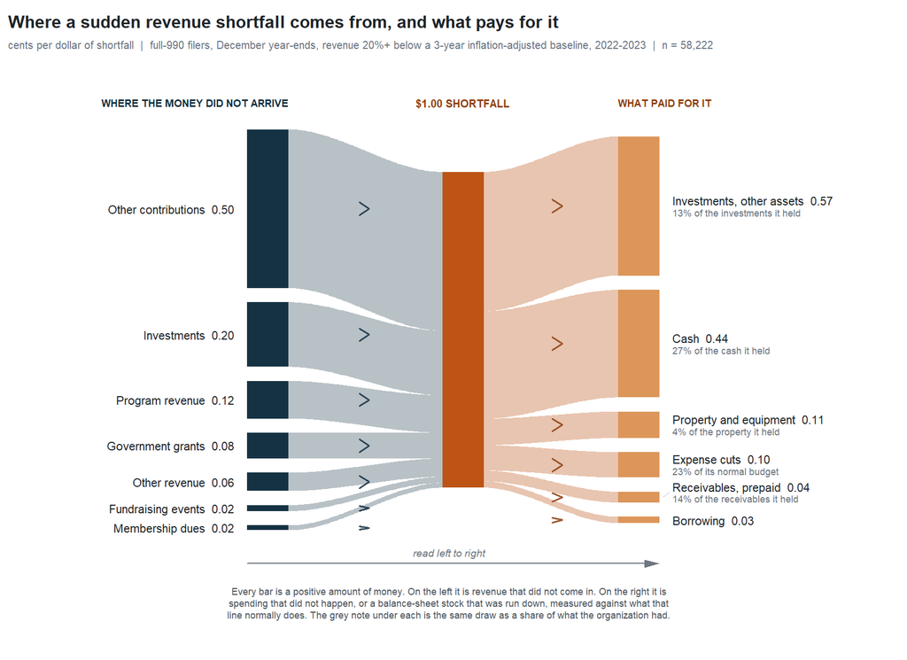

```r
pal <- c(ink = "#1f2429", ink_mid = "#4d565f", ink_soft = "#6d7681",
         accent = "#bd5416", accent_ink = "#8f3f10", navy = "#153243",
         pumpkin = "#dc965a", surface = "#f3f4f6")

flow_figure <- function(sources, uses, use_capacity_label, title, subtitle, dropped = NULL) {
  op <- par(mar = c(0.4, 0.4, 3.0, 0.4), bg = "white", family = "sans")
  on.exit(par(op))
  gap <- 0.045; centre <- 0.5
  lab_s <- sprintf("%s  %.2f", names(sources), sources)
  lab_u <- sprintf("%s  %.2f", names(uses), uses)
  sources_n <- sources / sum(sources); uses_n <- uses / sum(uses)

  half <- function(v) (sum(v) + gap * (length(v) - 1)) / 2
  top_max <- centre + max(half(sources_n), half(uses_n), 0.5)
  bot_min <- centre - max(half(sources_n), half(uses_n), 0.5)
  head_y  <- top_max + 0.085
  arrow_y <- bot_min - 0.105
  legend_y <- arrow_y - 0.075
  foot_y  <- legend_y - (if (length(dropped)) 0.185 else 0.115)
  plot.new(); plot.window(xlim = c(0, 1), ylim = c(foot_y - 0.02, head_y + 0.06))

  stack <- function(v) {
    y <- centre + half(v)
    out <- lapply(v, function(h) { r <- c(top = y, bot = y - h); y <<- y - h - gap; r })
    names(out) <- names(v); out
  }
  ribbon <- function(x0, x1, t0, b0, t1, b1, col, alpha) {
    t <- seq(0, 1, length.out = 80); s <- t * t * (3 - 2 * t); xs <- x0 + (x1 - x0) * t
    polygon(c(xs, rev(xs)), c(t0 + (t1 - t0) * s, rev(b0 + (b1 - b0) * s)),
            col = adjustcolor(col, alpha), border = NA)
  }
  # a chevron riding each ribbon, so the direction of travel is on the page
  chevron <- function(x, ytop, ybot, col) {
    ymid <- (ytop + ybot) / 2; h <- min(0.020, (ytop - ybot) / 2.6); w <- 0.012
    if (h <= 0.003) return(invisible())
    lines(c(x - w, x, x - w), c(ymid + h, ymid, ymid - h), col = col, lwd = 1.6)
  }
  xs <- c(0.250, 0.300); xt <- c(0.487, 0.537); xu <- c(0.700, 0.750)
  srcb <- stack(sources_n); useb <- stack(uses_n); top <- centre + 0.5

  # Thin bars sit closer together than their labels do, so the last few labels
  # in a stack collide. Push them apart from the bottom up and draw a leader
  # line back to the bar whenever a label has been moved off its own centre.
  place <- function(boxes, minsep) {
    y <- vapply(boxes, mean, 0); n <- length(y)
    if (n > 1) for (i in (n - 1):1) if (y[i] - y[i + 1] < minsep) y[i] <- y[i + 1] + minsep
    y
  }
  ys_lab <- place(srcb, 0.052)
  yu_lab <- place(useb, if (any(nzchar(use_capacity_label))) 0.088 else 0.052)
  leader <- function(x0, x1, y_bar, y_lab, col) {
    if (abs(y_lab - y_bar) < 0.004) return(invisible())
    lines(c(x0, x1), c(y_bar, y_lab), col = adjustcolor(col, 0.45), lwd = 0.7)
  }

  cur <- top
  for (i in seq_along(srcb)) {
    ribbon(xs[2], xt[1], srcb[[i]][["top"]], srcb[[i]][["bot"]], cur, cur - sources_n[[i]],
           pal[["navy"]], 0.30)
    chevron(0.398, srcb[[i]][["top"]], srcb[[i]][["bot"]], adjustcolor(pal[["navy"]], 0.85))
    cur <- cur - sources_n[[i]]
  }
  cur <- top
  for (i in seq_along(useb)) {
    ribbon(xt[2], xu[1], cur, cur - uses_n[[i]], useb[[i]][["top"]], useb[[i]][["bot"]],
           pal[["accent"]], 0.34)
    chevron(0.632, useb[[i]][["top"]], useb[[i]][["bot"]], adjustcolor(pal[["accent_ink"]], 0.85))
    cur <- cur - uses_n[[i]]
  }
  for (i in seq_along(srcb)) {
    rect(xs[1], srcb[[i]][["bot"]], xs[2], srcb[[i]][["top"]], col = pal[["navy"]], border = NA)
    leader(xs[1] - 0.004, xs[1] - 0.012, mean(srcb[[i]]), ys_lab[i], pal[["ink_soft"]])
    text(xs[1] - 0.016, ys_lab[i], lab_s[i], adj = c(1, 0.5), cex = 0.68, col = pal[["ink"]])
  }
  rect(xt[1], centre - 0.5, xt[2], top, col = pal[["accent"]], border = NA)
  for (i in seq_along(useb)) {
    rect(xu[1], useb[[i]][["bot"]], xu[2], useb[[i]][["top"]], col = pal[["pumpkin"]], border = NA)
    leader(xu[2] + 0.004, xu[2] + 0.012, mean(useb[[i]]), yu_lab[i], pal[["ink_soft"]])
    ym <- yu_lab[i]
    if (nzchar(use_capacity_label[i])) {
      text(xu[2] + 0.016, ym + 0.018, lab_u[i], adj = c(0, 0.5), cex = 0.68, col = pal[["ink"]])
      text(xu[2] + 0.016, ym - 0.020, use_capacity_label[i], adj = c(0, 0.5), cex = 0.56,
           col = pal[["ink_soft"]])
    } else {
      text(xu[2] + 0.016, ym, lab_u[i], adj = c(0, 0.5), cex = 0.68, col = pal[["ink"]])
    }
  }
  text(xs[2], head_y, "WHERE THE MONEY DID NOT ARRIVE", adj = c(1, 0.5), cex = 0.60,
       font = 2, col = pal[["navy"]])
  text(mean(xt), head_y, "$1.00 SHORTFALL", adj = c(0.5, 0.5), cex = 0.62, font = 2,
       col = pal[["accent_ink"]])
  text(xu[1], head_y, "WHAT PAID FOR IT", adj = c(0, 0.5), cex = 0.60, font = 2,
       col = pal[["accent_ink"]])
  lines(c(0.250, 0.740), c(arrow_y, arrow_y), col = pal[["ink_soft"]], lwd = 1)
  polygon(c(0.750, 0.732, 0.732), c(arrow_y, arrow_y + 0.013, arrow_y - 0.013),
          col = pal[["ink_soft"]], border = NA)
  text(0.495, arrow_y + 0.022, "read left to right", adj = c(0.5, 0), cex = 0.58,
       font = 3, col = pal[["ink_soft"]])
  text(0.495, legend_y,
       paste0("Every bar is a positive amount of money. On the left it is revenue that did not come in. ",
              "On the right it is\nspending that did not happen, or a balance-sheet stock that was run down, ",
              "measured against what that\nline normally does. The grey note under each is the same draw ",
              "as a share of what the organization had."),
       adj = c(0.5, 1), cex = 0.57, col = pal[["ink_mid"]])
  if (length(dropped)) {
    text(0.495, foot_y + 0.055,
         paste0("Came in above baseline during the shock, so not drawn: ",
                paste(dropped, collapse = "; "), ". The tables above keep the sign."),
         adj = c(0.5, 1), cex = 0.55, col = pal[["ink_soft"]], font = 3)
  }
  mtext(title, side = 3, line = 1.45, adj = 0, cex = 1.0, font = 2, col = pal[["ink"]])
  mtext(subtitle, side = 3, line = 0.45, adj = 0, cex = 0.64, col = pal[["ink_soft"]])
}

pick <- function(v) { v <- v[v > 0.005]; sort(v, decreasing = TRUE) }
src_v  <- setNames(src$cents_per_dollar, src$channel)
uses_v <- c(`Expense cuts` = ec,
            setNames(bs$cents_per_dollar, bs$channel)[
              c("Cash", "Investments, other assets", "Receivables, prepaid", "Property and equipment")],
            Borrowing = bs[channel == "Long-term debt", cents_per_dollar] +
                        bs[channel == "Short-term liabilities", cents_per_dollar] +
                        bs[channel == "Other liabilities", cents_per_dollar])
cap_v <- c(`Expense cuts` = pct_capacity(main_s, "cut_E"),
           Cash = pct_capacity(main_s, "bs_cash"),
           `Investments, other assets` = pct_capacity(main_s, "bs_othass"),
           `Receivables, prepaid` = pct_capacity(main_s, "bs_oca"),
           `Property and equipment` = pct_capacity(main_s, "bs_fixed"),
           Borrowing = (sum(main_s$dol_bs_lt) + sum(main_s$dol_bs_st) + sum(main_s$dol_bs_othli)) /
                       sum(main_s$boy_lt + main_s$boy_st + main_s$boy_other_liab))
cap_phrase <- c(`Expense cuts` = "its normal budget", Cash = "the cash it held",
                `Investments, other assets` = "the investments it held",
                `Receivables, prepaid` = "the receivables it held",
                `Property and equipment` = "the property it held",
                Borrowing = "the liabilities it owed")

sources_p <- pick(src_v); uses_p <- pick(uses_v)
dropped <- c(names(src_v)[src_v <= 0.005], names(uses_v)[uses_v <= 0.005])

# The capacity ratio weights organizations by dollars while the cents-per-dollar
# share weights them by the scaled channel, so the two can disagree in sign when
# a handful of very large organizations move one way and the many move the other.
# Borrowing does exactly that. A negative capacity note under a positive bar
# reads as an error rather than as the weighting difference it is, so it is left
# off the figure; the signed value stays in the section 7 table.
capk <- cap_v[names(uses_p)]
flow_figure(
  sources_p, uses_p,
  use_capacity_label = ifelse(is.na(capk) | capk <= 0, "",
                              sprintf("%.0f%% of %s", 100 * capk,
                                      cap_phrase[names(uses_p)])),
  title = "Where a sudden revenue shortfall comes from, and what pays for it",
  subtitle = paste0("cents per dollar of shortfall  |  full-990 filers, December year-ends, revenue ",
                    pct(params$shock_threshold, 0), "+ below a ", BW,
                    "-year inflation-adjusted baseline, 2022-2023  |  n = ",
                    format(nrow(main_s), big.mark = ",")),
  dropped = tolower(dropped))
```

Labels carry the true cents-per-dollar values; the bars are normalised to each side’s own total so the ribbons meet the centre exactly. The grey line under each right-hand label is that same draw as a share of what the organization had — the absorptive-capacity reading. Any channel that moved the other way is named under the figure and keeps its sign in the tables above.

# 12. Findings

- **The split.** Of each dollar of revenue that failed to arrive relative to a three-year inflation-adjusted baseline, 0.104 is matched by spending that did not happen and 0.896 is carried on the balance sheet.
- **What the old rule was measuring.** 25.3% of the organization-years the prior-year rule called a shock are rejected by the baseline rule, and their median prior year sat 30.4% above their own baseline. The v1 sample was substantially a windfall-reversion sample.
- **Cash.** 0.443 per dollar short comes out of cash, which is 27.0% of the cash these organizations were holding when the year began.
- **Borrowing.** 0.020 per dollar short is funded by new identified debt.
- **Reserves buffer the cut, and the effect is large.** The expense-cut share for low-reserve organizations is 0.393 against -0.105 for high-reserve organizations, which spend *above* baseline through the shock and draw 0.898 per dollar from cash instead — 48.2% of the cash they held. Within organizations the interaction agrees: a shock cuts expenses by 0.357, but high-reserve organizations cut 0.097 less and draw 0.341 more from cash. This is the behavioural claim the reserves dimension of the index rests on, and it holds.
- **Which line is lost matters far more than how much is lost.** Of a dollar of lost program revenue, 0.848 is matched by lower spending; of a dollar of lost membership dues, 0.951 is simply replaced from other sources and the expense response is essentially zero. A single “revenue shock” dimension in the index averages over a genuine four-to-one difference in how organizations respond.
- **The 20% threshold is weaker than it sounds.** A 20% shortfall against a three-year baseline is 0.69 robust standard deviations from the median and occurs in 23% of organization-years, and because volatility falls steeply with size it flags 34% of the smallest organizations against 15% of the largest. The absorption split is stable across thresholds, so no estimate here depends on it, but a size-relative cut point would be a better definition for the index.